# Final Project Presentation

Lindsay Nyman

Wednesday, December 08, 2021 @ 08:38 PM

##SETUP

```r
library(tidyverse)
library(ggplot2)
library(dplyr)
library(tidyr)
library(readr)
library(waffle)
library(DT)
```

## LOAD DATASET 1

```r
billionaires_2021_10_31 <- read_csv("dataraw/billionaires_2021_10_31.csv")
```

## VISUALIZATION 1

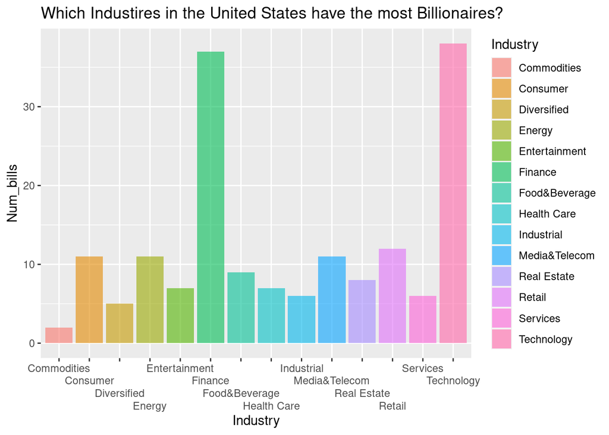

```r
#How many billionairs in the United State are in each Industry

bill1 <- filter(billionaires_2021_10_31, Country == c("UnitedStates"))

bill2 <- bill1 %>% arrange(Industry)

bill3 <- bill2 %>% count(Industry)

bill3 <- rename(bill3,
                Num_bills = n)


ggplot(bill3, aes(x= Industry , y= Num_bills, fill = Industry )) +
  geom_col(alpha = .6) +
  scale_x_discrete(guide = guide_axis(n.dodge = 4)) +
  labs(title = "Which Industires in the United States have the most Billionaires?")
```

## LOAD DATASET 2

```r
ramenratings <- read_csv("dataraw/ramenratings.csv")
```

## VISUALIZATION 2

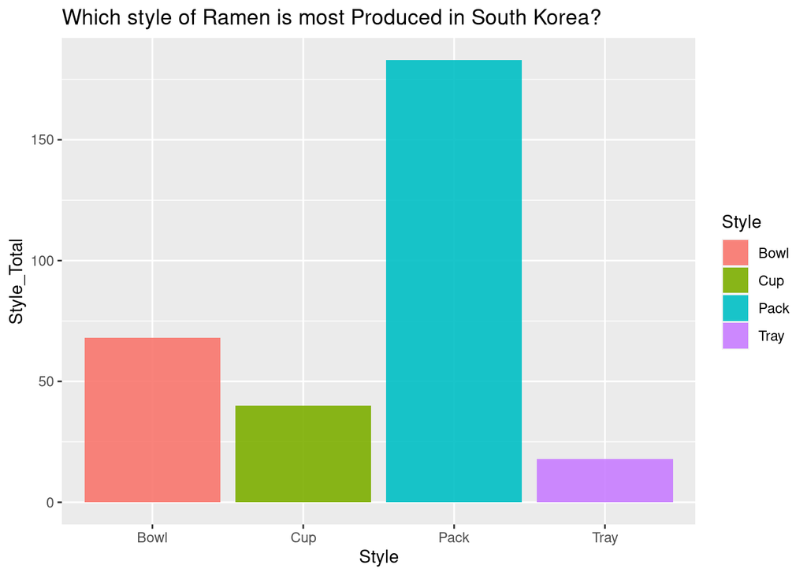

```r
#Which style of noodle has the best mean star rating
#Whichy style of moodle is most popular in SOuth Korea
ramen1 <- ramenratings %>% arrange(style)

ramen2 <- ramen1 %>% count(style)

ramen3 <- na.omit(ramen2)

ramen4 <- na.omit(ramen1)

ramen5 <- ramen1 %>% arrange(country)

ramenA <- filter(ramen1, country == "South Korea" )

ramenB <- ramenA %>% count(style)

ramenC <- rename(ramenB,
                 Style_Total = n,
                 Style = style)

ggplot(ramenC, aes(x = Style , y = Style_Total, fill = Style)) +
  geom_col(alpha = .9) +
  labs(title = "Which style of Ramen is most Produced in South Korea? ")
```

## Ramen Visualization Explanation

### I chose to use this data because it had a wide variety of opions when it came to reading the data. It has multiple ways to dive into the data and I wanted to work with a data set that had options in case soemthing didnt quite work correctly.

### The Ramen data set shows multiple countries in the worlds ramen production styles, ratings, and names among a few others. I chose to focus in on one Country in Specific which produced a large mount of Ramen, South Korea. Using a Bar graph you can clearly see that Pack style of Ramen is the most produced while Tray is the style least Produced.